# Project 2: COVID19 evolution

#### Name: Junhui(Locken) Liu

#### Sudent ID: 3037577959

The dataset covid_sequences.fa includes 200 sequences from the covid19 virus from different isolates across the world. A multiple sequence alignment of these sequences is found in the file covid_aligned_sequences.aln. These files are in “fast” format. Each sequence begins with header line that is prefixed a “>” character. The header includes a number of pieces of information about the sequence separated with “|” characters. e.g.

> NC_045512 |Severe acute respiratory syndrome coronavirus 2 isolate Wuhan-Hu-1| complete genome|China|Severe acute respiratory syndrome-related coronavirus|refseq| complete .

The header line is followed by the sequence which is spread across multiple lines until the next header line or the end of the file. Implement the following. Comment all code and submit alongside a brief writeup.

#### Import relevant package, original data, and caculated data.

```r
#relavant package
library("Biostrings")
#vignette("stringdist_C-Cpp_api", package="stringdist")
library("stringdist")
library(ggplot2)
library(foreach)
library(cluster)
```

```r
#original data
covid_sequences <- readAAStringSet('covid_sequences.fa', format="fasta", nrec=-1, skip=0, seek.first.rec=FALSE, use.names=TRUE)
head(covid_sequences)
covid_aligned_sequences <- readAAStringSet('covid_aligned_sequences.aln', format="fasta", nrec=-1, skip=0, seek.first.rec=FALSE, use.names=TRUE)
head(covid_aligned_sequences)
```

```
AAStringSet object of length 6:
    width seq                                               names
[1] 29902 TGCTTATGAAAATTTTAATCTCC...AAAAAAATTAATTTTAGTAGTGC LC528232 |Severe ...
[2] 29902 CCCCAAAATGCTGTTGTTTATAC...AAAACAGTGAACAATGCTAGGGA LC528233 |Severe ...
[3] 29903 ATTAAAGGTTTATACCTTCCCAG...AAAAAAAAAAAAAAAAAAAAAAA LC529905 |Severe ...
[4] 29878 AAGGTTTATACCTTCCCAGGTAA...AGGAGAATGACAAAAAAAAAAAA LC534418 |Severe ...
[5] 29874 CACCTTCCCAGGTAACAAACCAA...GAATGACAAAAAAAAAAAAAAAA LC534419 |Severe ...
[6] 29903 ATTAAAGGTTTATACCTTCCCAG...AAAAAAAAAAAAAAAAAAAAAAA LC542809 |Severe ...
```

```
AAStringSet object of length 6:
    width seq                                               names
[1] 30032 -----------------------...----------------------- emb|LR757997.1
[2] 30032 -----------------------...----------------------- gb|MT198651.1
[3] 30032 -----------------------...----------------------- gb|MT233520.1
[4] 30032 -----------------------...----------------------- gb|MT246465.1
[5] 30032 -----------------------...----------------------- gb|MT233521.1
[6] 30032 -----------------------...----------------------- gb|MT198653.1
```

```r
#calculated data, caculating these data is time-cosuming, can be calculated by the following code.
k100m <- read.csv("k100m.csv")
k100mname <- k100m$X
k100m <- k100m[,-1]
colnames(k100m) <- k100mname

k15m <- read.csv("k15m.csv")
k15mname <- k15m$X
k15m <- k15m[,-1]
colnames(k15m) <- k15mname

k30m <- read.csv("k30m.csv")
k30mname <- k30m$X
k30m <- k30m[,-1]
colnames(k30m) <- k30mname

k50m <- read.csv("k50m.csv")
k50mname <- k50m$X
k50m <- k50m[,-1]
colnames(k50m) <- k50mname

k_jaccard_dist <- read.csv("k_jaccard_dist.csv")[,-1]

hamDistmatrix <- read.csv("hamDistmatrix.csv")
hamDistmatrixname <- hamDistmatrix$X
hamDistmatrix <- hamDistmatrix[,-1]
colnames(hamDistmatrix) <- hamDistmatrixname

NewhamDist <- read.csv("NewhamDist.csv")
NewhamDistname <- NewhamDist$X
NewhamDist <- NewhamDist[,-1]
colnames(NewhamDist) <- NewhamDistname
```

#### 1. Implement code in python or R to compare the Jaccard distance between k-mers of any length from these sequences. *feel free to use any existing fasta parsers

```r
#Using function created by Locken...
kmersSeq <- function(seq,k){
  kmers_seq <- c()
  for (i in 1:(length(seq)-k+1)){
    kmers_seq <- c(kmers_seq, as.character(substr(seq, i,i+k-1)))
  }
  return (kmers_seq)
}

jaccard_distance <- function(setA, setB, k) {
  seqa <- kmersSeq(setA, k)
  seqb <- kmersSeq(setB, k)
  AandB <- intersect(seqa, seqb)
  AorB <- union(seqa, seqb)
  return(1-length(AandB) / length(AorB))
}
t1<- Sys.time()
jaccard_distance(covid_sequences[[2]], covid_sequences[[120]], 27)
t2<- Sys.time()
paste("Time consumed(s): ",t2-t1)
```

0.0373522302062982

'Time consumed(s): 32.1181538105011'

```r
#Using stringdist function from package "Biostring"
t1<- Sys.time()
stringdist(covid_sequences[[2]], covid_sequences[[120]], method='jaccard', q=27)
t2<- Sys.time()
paste("Time consumed(s): ",t2-t1)
```

0.0373522302062982

'Time consumed(s): 0.0382587909698486'

#### 2. Plot the distribution of inter-sequence Jaccard distances among all sequences for k=15, 30, 50, and 100. How do different k-mers lengths change the distribution of distances?

```r
#These codes are used to calculate k15m,k30m,k50m,k100m,which had been imported before, needing 2 hours to calculate them again.
#k15m <- matrix (data=NA, nrow = 200, ncol = 200, byrow = FALSE)
#k30m <- matrix (data=NA, nrow = 200, ncol = 200, byrow = FALSE)
#k50m <- matrix (data=NA, nrow = 200, ncol = 200, byrow = FALSE)
#k100m <- matrix (data=NA, nrow = 200, ncol = 200, byrow = FALSE)
#for (i in 1:199){
#  for (j in (i+1):200){
#    k15m[i,j] <- stringdist(covid_sequences[[i]], covid_sequences[[j]], method='jaccard', q=15)
#  }
#}
#for (i in 1:199){
#  for (j in (i+1):200){
#    k30m[i,j] <- stringdist(covid_sequences[[i]], covid_sequences[[j]], method='jaccard', q=30)
#  }
#}
#for (i in 1:199){
#  for (j in (i+1):200){
#    k50m[i,j] <- stringdist(covid_sequences[[i]], covid_sequences[[j]], method='jaccard', q=50)
#  }
#}
#for (i in 1:199){
#  for (j in (i+1):200){
#    k100m[i,j] <- stringdist(covid_sequences[[i]], covid_sequences[[j]], method='jaccard', q=100)
#  }
#}
#k <- c(rep('015', times=length(na.omit(c(k15m)))), rep('030', times=length(na.omit(c(k30m)))),
#       rep('050', times=length(na.omit(c(k50m)))),rep('100', times=length(na.omit(c(k100m)))))
#jaccard_dist <- c(na.omit(c(k15m)),na.omit(c(k30m)),na.omit(c(k50m)),na.omit(c(k100m)))
#k_jaccard_dist <- data.frame(k, jaccard_dist)
```

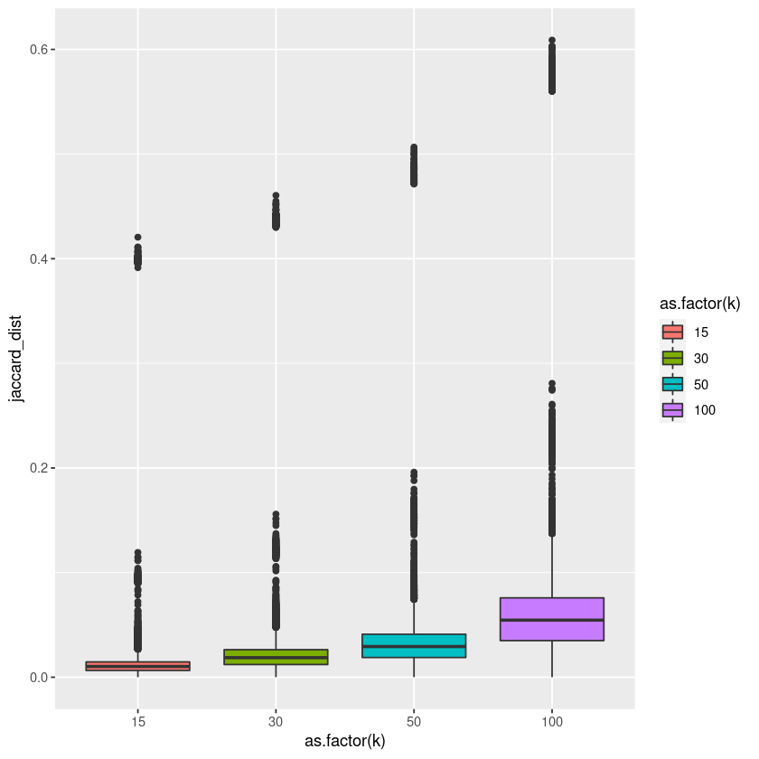

```r
ggplot(k_jaccard_dist, aes(x=as.factor(k), y=jaccard_dist, fill=as.factor(k))) +
  geom_boxplot()
```

###### The distribution of inter-sequence Jaccard distances among all sequences for different k-mers is plotted above. We can see that larger k-mers lengths leads to bigger jaccard distance.

#### 3. Use the aligned sequences file to calculate the hamming distance between all pairs of sequences. What happens when you ignore gaps (-) and N’s (N)?

##### Using the aligned sequences file to calculate the hamming distance between all pairs of sequences

This code is used to calculate hamDist,which had been imported before, needing 0.5 hours to calculate it again.

```r
#hamDist <- stringDist(covid_aligned_sequences, method ="hamming")
```

##### Ignoring gaps(-) and N's (N), using the aligned sequences file to calculate the hamming distance between all pairs of sequences.

##### I was not able to find a function off the shelf in R matching this criteria, so I thought of an nucleotide substitution matrix to calculate the hamming distance between sequences, the matrix is as follows:

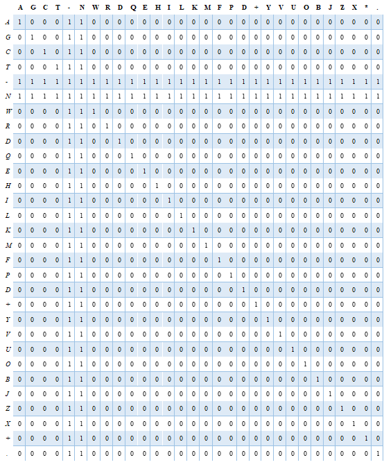

These codes are used to calculate the NewhamDist under new criteria, which had been imported before, needing approximatelt 10 hours to calculate it again.

```r
#NewhamDist <- as.matrix(hamDist)
#l <- length(covid_aligned_sequences[[1]])
#myScoringMat <- nucleotideSubstitutionMatrix(match = 1, mismatch = 0, baseOnly = TRUE)
#myScoringMat <- cbind(myScoringMat, matrix(1,4,2))
#myScoringMat <- cbind(myScoringMat, matrix(0,4,24))
#myScoringMat <- rbind(myScoringMat, matrix(0,26,30))
#myScoringMat[5:6,] <- 1
#myScoringMat[,5:6] <- 1
#for (i in 7:30){
#  myScoringMat[i,i] <- 1
#}
#myScoringMat
#colnames(myScoringMat) <- c("A","G","C","T","-","N","W","R","D","Q",
#                            "E","H","I","L","K","M","F","P","S","+",
#                            "Y","V","U","O","B","J","Z","X","*",".")
#rownames(myScoringMat) <- c("A","G","C","T","-","N","W","R","D","Q",
#                            "E","H","I","L","K","M","F","P","S","+",
#                            "Y","V","U","O","B","J","Z","X","*",".")

#NEWH <- function(seq1,seq2){
#  return (l-pairwiseAlignment(seq1,seq2,
#                      substitutionMatrix = myScoringMat,
#                      gapOpen = 0, gapExtension = 0,
#                      type="global", scoreOnly = TRUE))
#}

#for(i in 1:199){
#  cl <- makeCluster(12)
#  registerDoParallel(cl)
#  time1 <- Sys.time()
#  result <- foreach (j = (i+1):200, .combine = c, .packages = 'Biostrings',.errorhandling = "stop")%dopar%{
#    NEWH(covid_aligned_sequences[[i]], covid_aligned_sequences[[j]])
#  }
#  time2 <- Sys.time()
#  print(time2-time1)
#  stopImplicitCluster()
#  stopCluster(cl)
#  NewhamDist[i,(i+1):200] <- result
#  NewhamDist[(i+1):200,i] <- result
#}
```

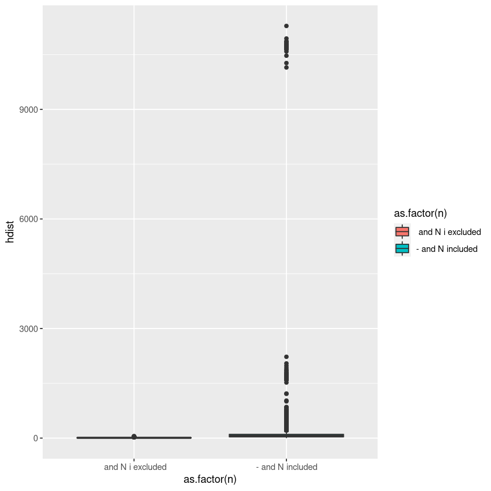

```r
hamDistc <- as.matrix(hamDistmatrix)
hamDistc[!upper.tri(hamDistc, diag = FALSE)] <- NA
hamDistc <- na.omit(c(hamDistc))

NewhamDistc <- as.matrix(NewhamDist)
NewhamDistc[!upper.tri(NewhamDistc, diag = FALSE)] <- NA
NewhamDistc <- na.omit(c(NewhamDistc))

n <- c(rep('- and N included', times=length(hamDistc)), rep(' and N i excluded', times=length(NewhamDistc)))
hdist <- c(hamDistc,NewhamDistc)
n_ham_dist<-data.frame(n, hdist)
ggplot(n_ham_dist, aes(x=as.factor(n), y=hdist, fill=as.factor(n))) +
  geom_boxplot()
```

##### When gaps (-) and N’s (N) are ignored, the hamming distance becomes much smaller between sequeces.

#### 4. Build a tree using the UPGMA algorithm from hamming distances calculated excluding gapped sequence. Feel free to use existing R or python functions to perform UPGMA clustering, and plot the final tree.

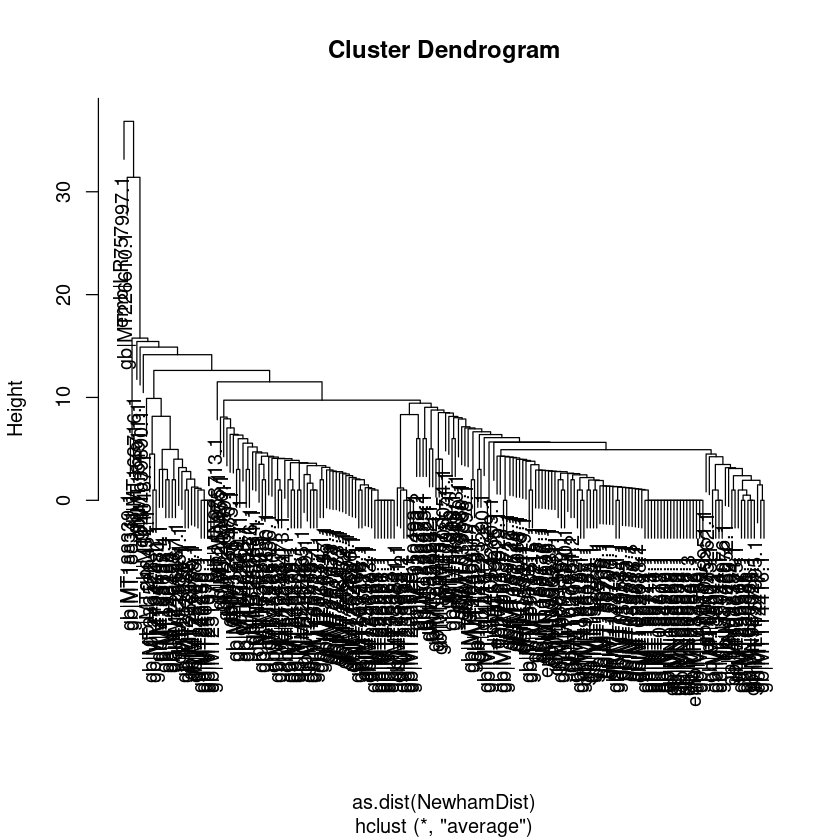

```r
clusters2 <- hclust(as.dist(NewhamDist), method = "average")
plot(clusters2)
```

###### From this tree, we can only roughly judge the similarity between sequences during the evolution of the COVID. But because there are so many sequences and their names are overlapped together, I can't even see them clearly.

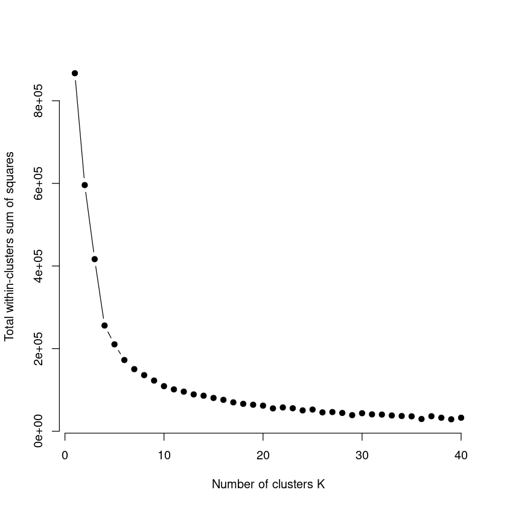

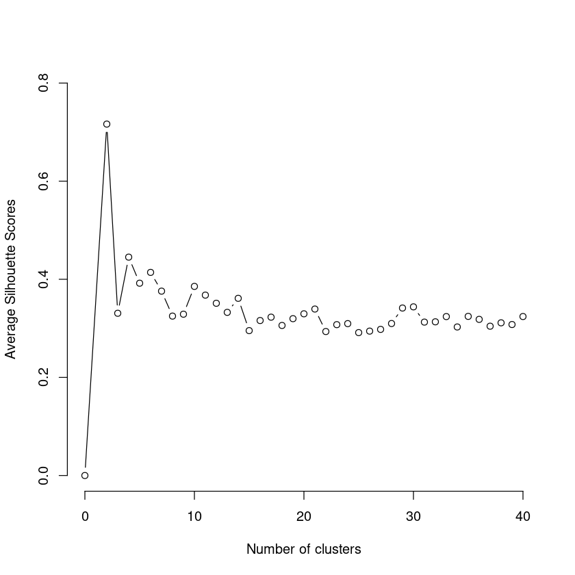

```r
k.max <- 40 #max 150 (num of obs)
twcss <- sapply(1:k.max,
              function(k){kmeans(NewhamDist, k, nstart=40)$tot.withinss})

plot(1:k.max, twcss,
     type="b", pch = 19, frame = FALSE,
     xlab="Number of clusters K",
     ylab="Total within-clusters sum of squares")

#silhouette method
avg_silhouette_score <- function(k){
  km <- kmeans(NewhamDist, centers = k, nstart=40)
  ss <- silhouette(km$cluster, dist(NewhamDist, "euclidean"))
  mean(ss[, 3])
}
k <- 2:40 #minimum number of clusters for silhouette scores is 2 for between-cluster variation
avg_sil <- sapply(k, avg_silhouette_score)
k <- c(0, k)
avg_sil <- c(0, avg_sil)
plot(k, avg_sil, type='b', xlab='Number of clusters', ylab='Average Silhouette Scores', frame=FALSE, ylim = c(0,0.8))
```

```r
library("ggdendro")
library("dplyr")
library("dendextend")
library("ape")
```

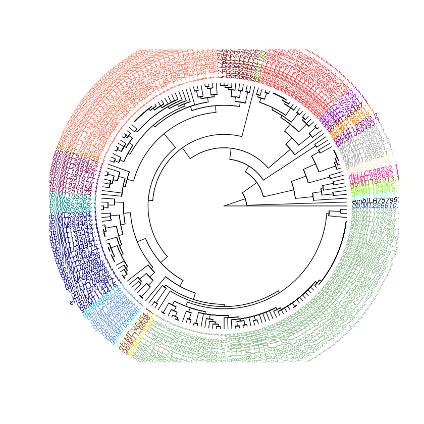

```r
colors <- c("#000000","#A9A9A9", "#8B1A1A", "#FF3030", "#FF7256", "#FF1493", "#9400D3", "#8B0A50", "#104EBB",
            "#1E90FF","#00BFFF", "#97FFFF", "#C1FFC1", "#8FBC8F", "#7FFF00", "#FFD700", "#FFEBCD", "#8B7500",
            "#8B4513","#458B00", "#6495ED", "#00008B", "#008B8B", "#8B008B", "#FF7F00", "#CD6600", "#8B0000")
cluster4 <- as.dist(NewhamDist) %>% hclust
clus4 <- cutree(cluster4, 27)
plot(as.phylo(cluster4), type = "fan", tip.color = colors[clus4],
     label.offset = 1, cex = 0.7)
```

###### Phylogenetic trees in the shape of fan can be good to see the names clearly.

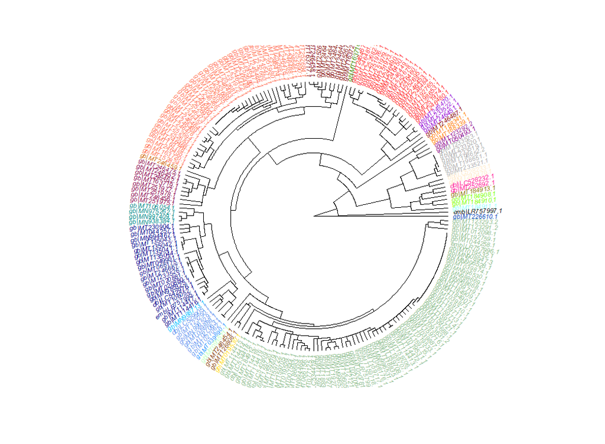

emb|MT226610: |Severe acute respiratory syndrome coronavirus 2 isolate SARS-CoV-2/human/CHN/KMS1/2020| complete genome|China|Severe acute respiratory syndrome-related coronavirus|complete"

emb|LR757997: |Wuhan seafood market pneumonia virus genome assembly| chromosome: whole_genome|China|Severe acute respiratory syndrome-related coronavirus|

emb|MT184908: |Severe acute respiratory syndrome coronavirus 2 isolate 2019-nCoV/USA-CruiseA-21/2020| complete genome|USA|Severe acute respiratory syndrome-related coronavirus|complete"

emb|MT184910: |Severe acute respiratory syndrome coronavirus 2 isolate 2019-nCoV/USA-CruiseA-23/2020| complete genome|USA|Severe acute respiratory syndrome-related coronavirus|complete"

emb|MT246486: |Severe acute respiratory syndrome coronavirus 2 isolate SARS-CoV-2/human/USA/WA-UW229/2020| complete genome|USA|Severe acute respiratory syndrome-related coronavirus|complete"

emb|MT246464: |Severe acute respiratory syndrome coronavirus 2 isolate SARS-CoV-2/human/USA/WA-UW207/2020| complete genome|USA|Severe acute respiratory syndrome-related coronavirus|complete"

emb|MT114418: |Severe acute respiratory syndrome coronavirus 2 isolate SARS-CoV-2/human/HKG/HKU-908a/2020| complete genome|Hong Kong|Severe acute respiratory syndrome-related coronavirus|complete"

emb|LC542809: |Severe acute respiratory syndrome coronavirus 2 TKYE6947_2020 RNA| complete genome|Japan|Severe acute respiratory syndrome-related coronavirus|"

emb|MT159706: |Severe acute respiratory syndrome coronavirus 2 isolate 2019-nCoV/USA-CruiseA-8/2020| complete genome|USA|Severe acute respiratory syndrome-related coronavirus|complete"

#### 5. Write up a few sentences about what you infer from this tree and the evolution of the virus across the world.

When COVID first broke out, the rate of evolution was fast. The number of sequences in each cluster is small, and the sequences in the cluster see that the hammering distance is large; However, it's also possible that COVID 19 had started to evolve for some time before it was discovered. For example, the hamming distance between the sequence emb|LR757997 found in China in the early stage of the outbreak and the sequence emb|MT184908 found in the United States is very large. It may be because these two sequences were discovered in the early stage of the outbreak, when the evolvement rate is fast. But it is also can be the reason that COVID19 had started to evolve for some time before they were found, leading to great hamming distance.

With the further prevalence of COVID, clusters with a large number of sequences gradually appeared, and the hamming distance between sequences within the cluster was small, and even the hamming distance between several sequences can be zero. It indicated that the evolution rate slowed down and the COVID sequence gradually stabilized worldwide.Foe example, the sequence MT114418, LC542809, MT159706 were from different part of world, but there are extremely small hamming distances between them, showing the evolution slows down and becomes stable.

#### 6.Bonus: How is the data presented on https://nextstrain.org an improvement on the results generated here?

1. Its Phylogeny has more and more exhaustive data, including 2811 genomes sampled between Dec 2019 and May 2022.
2. Its Phylogeny has a more detailed introduction to the time, variant, and collection country of each data collection.
3. What interests me the most, and I have always wanted to implement it in my project, but what I did not achieve in the end is the interactivity of its Phylogeny, which can directly obtain relevant information by interacting with the web page.
4. In addition, it also displays other icons, directly marking the density of COVID19 variants in various places on the world map, the current frequency of COVID19 variants, and so on.